# Filtering of resequencing data

[figure not shown]

Figure 1: Coverage distributions for three hypothetical samples along with the cumulative coverage for all samples.

Discuss different types of relevant filters, e.g.

- filtering on read depth, both high to eliminate collapsed repeats, and low for mappability issues. This is particularly important for incomplete assemblies
- also briefly mention filtering on polymorphic sites

## Intended learning outcomes

- create per sample, per population, and total depth of coverage profiles
- generate mask files for downstream processing

## Tools

- mosdepth (Pedersen & Quinlan, 2018)
- samtools (Danecek et al., 2021)
- [csvtk](https://bioinf.shenwei.me/csvtk/)
- [bedtools](https://bedtools.readthedocs.io/en/latest/index.html) (Quinlan & Hall, 2010)
- [seqkit](https://bioinf.shenwei.me/seqkit/) (Shen et al., 2016)

## Input data

We will be working with the Out of Africa dataset, consisting of 10 samples from the CEU, CHB, and YRI populations. The input consists of 10 bam files:

```bash
ls -lLh [CY]*.chr21.bam
```

```
-rw-r--r-- 1 runner docker 7.8M Sep 28 01:51 CEU-1.ooa.chr21.bam
-rw-r--r-- 1 runner docker 6.3M Sep 28 01:51 CEU-2.ooa.chr21.bam
-rw-r--r-- 1 runner docker 4.8M Sep 28 01:51 CEU-3.ooa.chr21.bam
-rw-r--r-- 1 runner docker  13M Sep 28 01:51 CEU-4.ooa.chr21.bam
-rw-r--r-- 1 runner docker 5.8M Sep 28 01:51 CHB-1.ooa.chr21.bam
-rw-r--r-- 1 runner docker 5.2M Sep 28 01:51 CHB-2.ooa.chr21.bam
-rw-r--r-- 1 runner docker 6.5M Sep 28 01:51 CHB-3.ooa.chr21.bam
-rw-r--r-- 1 runner docker 6.1M Sep 28 01:51 YRI-1.ooa.chr21.bam
-rw-r--r-- 1 runner docker 6.0M Sep 28 01:51 YRI-2.ooa.chr21.bam
-rw-r--r-- 1 runner docker 7.6M Sep 28 01:51 YRI-3.ooa.chr21.bam
```

Each population consists of a collection – or set – of samples, and we will sometimes use the term `sample set` to refer to such a collection. For instance, the population (sample set) `CHB` consists of the set of samples `CHB-1`, `CHB-2` and `CHB-3`.

## Coverage analyses

Mapped reads provide information about how well a given genomic region has been represented during sequencing, and this information is usually summarized as the sequencing coverage. For any locus, this is equivalent to the number of reads mapping to that locus.

Sequencing coverage is typically not uniformly distributed over the reference. Reasons may vary but include uneven mapping coverage due to repeat regions, low coverage due to mis-assemblies, or coverage biases generated in the sequencing process. Importantly, both variable and monomorphic sites must be treated identically in the filtering process to eliminate biases between the two kinds of sites.

In this part, we will use `mosdepth` and `bedtools` to quickly generate depth of coverage profiles of mapped data. `mosdepth` is an ultra-fast command line tool for calculating coverage from a bam file. By default, it generates a summary of the global distribution, and per-base coverage in `bed.gz` format. We will be using the per-base coverage for filtering.

Alternatively, `mosdepth` can also output results in a highly compressed format `d4`, which has been developed to handle the ever increasing size of resequencing projects. Files in d4 format can be processed with the [d4-tools](https://github.com/38/d4-format) tool (Hou et al., 2021). For instance, `d4tools view` will display the coverage in `bed` format. We mention this in passing as it may be relevant when working with large genomes or sample sizes, but given the size of our sample data, we will be using `bedtools` from now on.

### Per sample coverage

We start by calculating per-sample coverages with `mosdepth`. For downstream purposes, we need to save the size of the chromosomes we’re looking at, and for many applications, a fasta index file is sufficient.

```bash
samtools faidx ooa.chr21.ref.fa
```

The syntax to generate coverage information for a bam file is `mosdepth <prefix> <input file>`. Here, we add the `-Q` option to exclude reads with a mapping quality less than 20:

```bash
mosdepth -Q 20 CEU-1 CEU-1.ooa.chr21.bam
```

The per-base coverage output file will be named `CEU-1.per-base.bed.gz` and can be viewed with `bgzip`:

```bash
bgzip -c -d CEU-1.per-base.bed.gz | head -n 5
```

```
chr21   0   7   0
chr21   7   22  1
chr21   22  45  2
chr21   45  47  3
chr21   47  54  4
```

To get an idea of what the coverage looks like over the chromsome, we can use `bedtools` and `cvstk` in a one-liner to generate a simple coverage plot (Figure 2)[^1]

```bash
bedtools intersect -a <(bedtools makewindows -g ooa.chr21.ref.fa.fai -w 5000) \
      -b CEU-1.per-base.bed.gz -wa -wb | \
  bedtools groupby -i - -g 1,2,3 -c 7 -o mean | \
  csvtk plot -t line -x 2 -y 4 --point-size 0.01 --xlab Position \
      --ylab Coverage --width 9.0 --height 3.5 > fig-plot-coverage.png
```

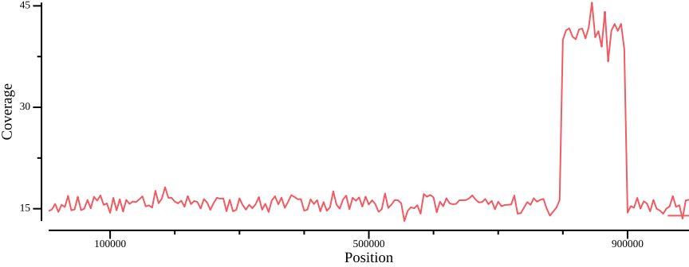

Figure 2: Coverage for sample CEU-1 in 5kb windows. Experiment changing the window size (`-w`) parameter to change smoothing.

Apparently there are some high-coverage regions that could be associated with, e.g., collapsed repeat regions in the assembly. Let’s compile coverage results for all samples, using bash string manipulation to generate file prefix[^2]

```bash
for f in [CY]*.chr21.bam; do
  prefix=${f%.ooa.chr21.bam}
  mosdepth -Q 20 $prefix $f
  echo -e -n "$prefix\t"
  cat $prefix.mosdepth.summary.txt | grep total
done > ALL.mosdepth.summary.txt
cat ALL.mosdepth.summary.txt
```

```
CEU-1   total   1000000 17917183    17.92   0   68
CEU-2   total   1000000 14292139    14.29   0   67
CEU-3   total   1000000 10428655    10.43   0   52
CEU-4   total   1000000 30572047    30.57   0   115
CHB-1   total   1000000 12830597    12.83   0   62
CHB-2   total   1000000 11392259    11.39   0   52
CHB-3   total   1000000 14835251    14.84   0   60
YRI-1   total   1000000 13699799    13.70   0   63
YRI-2   total   1000000 13437937    13.44   0   59
YRI-3   total   1000000 17218621    17.22   0   69
```

We can calculate the total coverage with `csvtk` as follows:

```bash
csvtk summary -H -t ALL.mosdepth.summary.txt -f 5:sum
```

to get the total coverage 156.63, which gives a hint at where the diploid coverage peak should be.

### Sample set coverages

We can combine coverage intervals with `bedtools unionbedg`. We collect the bed file names and generate matching sample names to pass as arguments to option `-names`. Also, we include positions with no coverage (`-empty`) which requires the use of a genome file (option `-g`). The bed output is piped to `bgzip` which compresses the output, before finally indexing with `tabix`:

```bash
BEDGZ=$(for f in *.per-base.bed.gz; do echo "$f "; done)
SAMPLES=$(for f in $BEDGZ; do echo -e -n "${f%.per-base.bed.gz} "; done)
bedtools unionbedg -header -names $SAMPLES -g ooa.chr21.ref.fa.fai -empty -i $BEDGZ | bgzip > ALL.bg.gz
tabix -f -p bed -S 1 ALL.bg.gz
```

We also need to combine coverages per populations CEU, CHB, and YRI. Using the previous command as a template, try to generate per population coverage files.

```bash
for pop in CEU CHB YRI; do
  BEDGZ=$(for f in ${pop}*.per-base.bed.gz; do echo "$f "; done)
  SAMPLES=$(for f in $BEDGZ; do echo -e -n "${f%.per-base.bed.gz} "; done)
  bedtools unionbedg -header -names $SAMPLES -g ooa.chr21.ref.fa.fai -empty -i $BEDGZ | bgzip > $pop.bed.gz
  tabix -f -p bed -S 1 $pop.bed.gz
done
```

### Total coverage

Since we eventually want to filter on total coverage, we sum per sample coverages for each sample set with `awk`:

```bash
bgzip -c -d ALL.bg.gz | awk -v FS="\t" -v OFS="\t" 'NR > 1 {sum=0; for (i=4; i<=NF; i++) sum+=$i; print $1, $2, $3, sum}' | bgzip > ALL.sum.bed.gz
tabix -f -p bed ALL.sum.bed.gz
```

For illustration, we plot the total coverage:

```bash
bedtools intersect -a <(bedtools makewindows -g ooa.chr21.ref.fa.fai -w 5000) \
    -b ALL.sum.bed.gz -wa -wb | \
  bedtools groupby -i - -g 1,2,3 -c 7 -o mean | \
  csvtk plot -t line -x 2 -y 4 --point-size 0.01 --xlab Position \
    --ylab Coverage --width 9.0 --height 3.5 > fig-plot-total-coverage.png
```

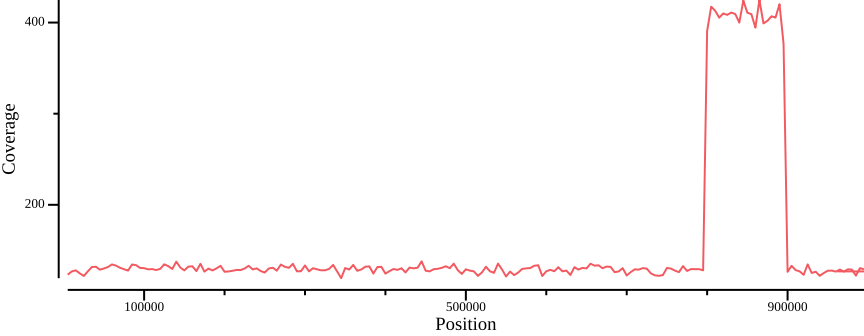

Figure 3: Total coverage in 5kb windows.

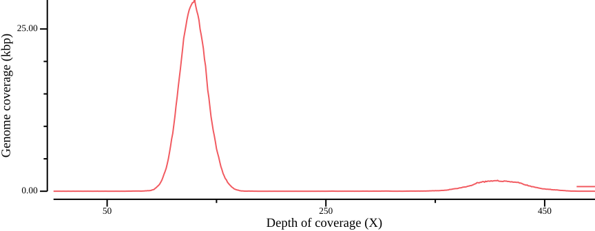

(a) Genome coverage

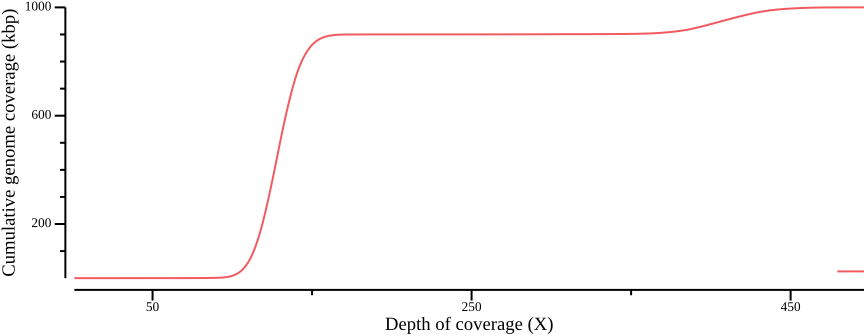

(b) Cumulative genome coverage

Figure 4: Genome coverage vs depth of coverage.

```bash
cat ALL.sum.bed.csv | \
  csvtk plot line -x 1 -y 2 --point-size 0.01 \
    --xlab "Depth of coverage (X)" --ylab "Genome coverage (kbp)" \
    --width 9.0 --height 3.5 --x-min 90 --x-max 160
```

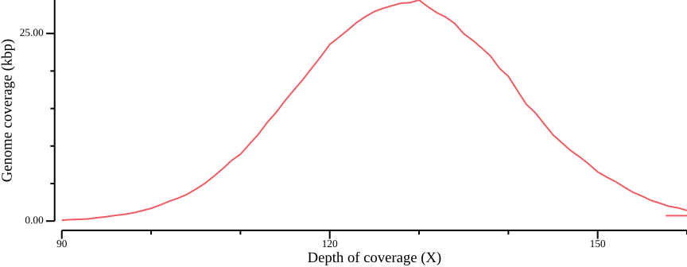

(a) Genome coverage

Figure 5: Genome coverage vs depth of coverage.

(Lou et al., 2021) point out that appropriate thresholds depend on the data set, but as a general rule recommends a minimum depth threshold at <0.8x average coverage, and a maximum depth threshold at mean coverage plus one or two standard deviations. Given the unrealistically homogenous coverage of our simulated data, we set thresholds based on Figure 5 to e.g., 100-160.

We then use these thresholds to generate a bed file containing regions that are accessible, i.e., have sufficient coverage for downstream analyses. We also calculate the number of bases that pass the filtering criteria.

```bash
zcat ALL.sum.bed.gz | awk '{if (($4 >= 100) && ($4 <= 160)) print $0}' > ALL.sum.depth.bed.gz
bedtools genomecov -i ALL.sum.depth.bed.gz -g ooa.chr21.ref.fa.fai  | grep genome
```

```
genome  0   112885  1000000 0.112885
genome  1   887115  1000000 0.887115
```

Consequently, 88.7% of the genome is accessible by depth.

**Exercise**

Generate coverage sums for sample sets CEU, CHB, and YRI, and from these determine coverage thresholds and apply the thresholds to generate bed files with accessible regions.

```bash
for pop in CEU CHB YRI; do
  bgzip -c -d $pop.bed.gz | \
    awk -v FS="\t" -v OFS="\t" 'NR > 1 {sum=0; for (i=4; i<=NF; i++) sum+=$i; print $1, $2, $3, sum}' | \
    bgzip > $pop.sum.bed.gz
  tabix -f -p bed $pop.sum.bed.gz
  zcat $pop.sum.bed.gz | \
    awk -v h=0 'BEGIN {OFS=","; cumsum=0} {a[$4] += ($3-$2)/1000; if ($4 > h) {h=$4}} END{for (i=0; i<=h; i++) {if (a[i]) {cumsum+=a[i]} else {a[i]=0;} print i, a[i], cumsum}}' \
    > $pop.sum.bed.csv
done
```

```bash
for pop in CEU CHB YRI; do
cat ${pop}.sum.bed.csv | \
  csvtk plot line -x 1 -y 2 --point-size 0.01 \
    --xlab "Depth of coverage (X)" --ylab "Genome coverage (kbp)" \
    --width 9.0 --height 3.5 --x-min 10 --x-max 100 > \
    fig-plot-total-coverage-distribution-hist-zoom-in-$pop.png
done
```

[output not shown]

Now we have combined total per sample coverage for ALL samples, and for sample sets CEU, CHB, and YRI. The upcoming task will be to generate sequence masks from the total coverage and minimum number of individuals with coverage greater than zero.

### Filter on minimum number of individuals

In addition to filtering on coverage, we will also filter on the minimum number of individuals with calls. This is to account for cases where coverages that pass the coverage filter originate from just a few samples. Here, we will remove sites where less than 50% of individuals have a call.

```bash
bgzip -c -d ALL.bg.gz | \
  awk -v FS="\t" 'BEGIN {OFS="\t"} NR > 1 {count=0; for (i=4; i<=NF; i++) {if ($i>0) count+=1}; if (count>=((NF-3)*0.5)) {print $1, $2, $3}}' | \
  bgzip > ALL.ind.bed.gz
tabix -f -p bed ALL.ind.bed.gz
```

#### Exercise

```bash
for pop in CEU CHB YRI; do
  bgzip -c -d $pop.bed.gz | awk -v FS="\t" 'BEGIN {OFS="\t"} NR > 1 {count=0; for (i=4; i<=NF; i++) {if ($i>0) count+=1}; if (count>=((NF-3)*0.5)) {print $1, $2, $3}}' | bgzip > $pop.ind.bed.gz
  tabix -f -p bed $pop.ind.bed.gz
done
```

## Sequence masks

Finally, for each sample set, we will use `bedtools intersect` to generate combined bed files for total sum coverages and the filter on number of individuals. `bedtools intersect` makes it easy to combine multiple bed files, so other filters could be added.

```bash
# bedtools intersect -a ALL.sum.bed.gz -b ALL.ind.bed.gz \
# -g ooa.chr21.ref.fa.fai | bgzip > ALL.mask.bed.gz
#tabix -f -p bed ALL.mask.bed.gz
```

```bash
awk 'BEGIN {OFS="\t"} {print $1, 0, $2}' ooa.chr21.ref.fa.fai > ooa.chr21.ref.fa.bed
bedtools maskfasta -fi ooa.chr21.ref.fa -mc 1 -fo ooa.chr21.mask.ref.fa -bed ooa.chr21.ref.fa.bed
```

# Variant filtering

1. p-value
2. multi-allelic sites (but illustrate case where one subpop may be tri-allelic but sister populations bi-allelic - for sub-population specific analyses the latter should not be removed)
3. MAF filter - for many analyses low-frequency snps are uninformative (e.g. PCA, LD) and can bias results

## References

Danecek, P., Bonfield, J. K., Liddle, J., Marshall, J., Ohan, V., Pollard, M. O., Whitwham, A., Keane, T., McCarthy, S. A., Davies, R. M., & Li, H. (2021). Twelve years of SAMtools and BCFtools. *GigaScience*, *10*(2), giab008. https://doi.org/10.1093/gigascience/giab008

Hou, H., Pedersen, B., & Quinlan, A. (2021). Balancing efficient analysis and storage of quantitative genomics data with the D4 format and D4tools. *Nature Computational Science*, *1*(6), 441–447. https://doi.org/10.1038/s43588-021-00085-0

Li, H. (2014). Toward better understanding of artifacts in variant calling from high-coverage samples. *Bioinformatics*, *30*(20), 2843–2851. https://doi.org/10.1093/bioinformatics/btu356

Lou, R. N., Jacobs, A., Wilder, A. P., & Therkildsen, N. O. (2021). A beginner’s guide to low-coverage whole genome sequencing for population genomics. *Molecular Ecology*, *30*(23), 5966–5993. https://doi.org/10.1111/mec.16077

Pedersen, B. S., & Quinlan, A. R. (2018). Mosdepth: Quick coverage calculation for genomes and exomes. *Bioinformatics*, *34*(5), 867–868. https://doi.org/10.1093/bioinformatics/btx699

Quinlan, A. R., & Hall, I. M. (2010). BEDTools: A flexible suite of utilities for comparing genomic features. *Bioinformatics*, *26*(6), 841–842. https://doi.org/10.1093/bioinformatics/btq033

Shen, W., Le, S., Li, Y., & Hu, F. (2016). SeqKit: A Cross-Platform and Ultrafast Toolkit for FASTA/Q File Manipulation. *PLOS ONE*, *11*(10), e0163962. https://doi.org/10.1371/journal.pone.0163962

## Footnotes

[^1]: The one-liner combines the results of several commands in a pipe stream. Also, [Bash redirections](https://www.gnu.org/software/bash/manual/html_node/Redirections.html) are used to gather the results from the output of `bedtools makewindows` to `bedtools intersect`. The intersection commands collects coverage data in 5kb windows that are then summarized by `bedtools groupby`.
[^2]: The `%` operator deletes the shortest match of `$substring` from back of `$string`: `${string%substring}`. See [Bash string manipulation](https://tldp.org/LDP/abs/html/string-manipulation.html) for more information.